# Regression

Group8

2021/2/28

# Continuous Regression

### Preparation

To start our new R Markdown, we need change the title and author name. And then import all packages we usually used and clean the global environment.

```r
library(haven)
library(tidyverse)
library(pander)
library(dplyr)
rm(list=ls())
```

Let’s import our merged data from GitHub. **Reminder** If you are located within Mainland China, you could have trouble in import data from GitHub even you could open the website of GitHub. So it will be better if you could use VPN service once you encounter these difficulties.

```r
#
data <- read.csv("https://raw.githubusercontent.com/Group8-GovAnalyticsProject/Merging/main/final_merged_data.csv")
```

### State the hypotheses

We already have many data and I assume that there is a relationship between the positive rate and median age of a tract. But whether it will be better if we add one more independent variable, income. So we get these two hypotheses to compare.

```r
# Hypothesis 1: Positive rate increases as median age larger.
hypo1=formula(precount_positive~median_age)
# Hypothesis 2: Positive rate increases as median age larger, income decreases.
hypo2=formula(precount_positive~median_age*median_hhold_inc)
```

### Build and compute the regression models

We build two generalized linear models for these two hypotheses.

```r
model_1=glm(hypo1,
         data=data,
         family="gaussian")
model_2=glm(hypo2,
         data=data,
         family="gaussian")
```

### Read the result

*Result for model/hypotheses 1*

```r
pander(summary(model_1))
```

|  | Estimate | Std. Error | t value | Pr(>\|t\|) |
| --- | --- | --- | --- | --- |
| **(Intercept)** | 34.46 | 4.58 | 7.524 | 3.713e-13 |
| **median_age** | -0.4703 | 0.118 | -3.985 | 8.064e-05 |

(Dispersion parameter for gaussian family taken to be 159.4836 )

| Null deviance: | 64731 on 391 degrees of freedom |
| --- | --- |
| Residual deviance: | 62199 on 390 degrees of freedom |

*Result for model/hypotheses 2*

```r
pander(summary(model_2))
```

|  | Estimate | Std. Error | t value | Pr(>\|t\|) |
| --- | --- | --- | --- | --- |
| **(Intercept)** | 42.1 | 11.13 | 3.782 | 0.00018 |
| **median_age** | -0.3418 | 0.2863 | -1.194 | 0.2332 |
| **median_hhold_inc** | -0.0002015 | 0.0001148 | -1.755 | 0.08011 |
| **median_age:median_hhold_inc** | 1.954e-06 | 2.833e-06 | 0.6898 | 0.4907 |

(Dispersion parameter for gaussian family taken to be 141.6419 )

| Null deviance: | 64731 on 391 degrees of freedom |
| --- | --- |
| Residual deviance: | 54957 on 388 degrees of freedom |

*Compare the two models and find the better one*

```r
anova(model_1,model_2,test="Chisq")
```

```
## Analysis of Deviance Table
##
## Model 1: precount_positive ~ median_age
## Model 2: precount_positive ~ median_age * median_hhold_inc
##   Resid. Df Resid. Dev Df Deviance  Pr(>Chi)
## 1       390      62199
## 2       388      54957  2   7241.5 7.911e-12 ***
## ---
## Signif. codes:  0 '***' 0.001 '**' 0.01 '*' 0.05 '.' 0.1 ' ' 1
```

For comparing these two models, we use the Anova function to perform the Chi-Square test. From the result, due to the p-value = 7.911e-12, these two models has statistical differences. And model 2 is better than model 1 because DF and residential are smaller. Then, we get the RSquared by using following codes.

```r
RSquare_1 <- rsq::rsq(model_1,adj=T)
RSquare_2 <- rsq::rsq(model_2,adj=T)
```

### Summary plots

We could get a plot and see the coefficient estimates.

```r
library(dotwhisker)
```

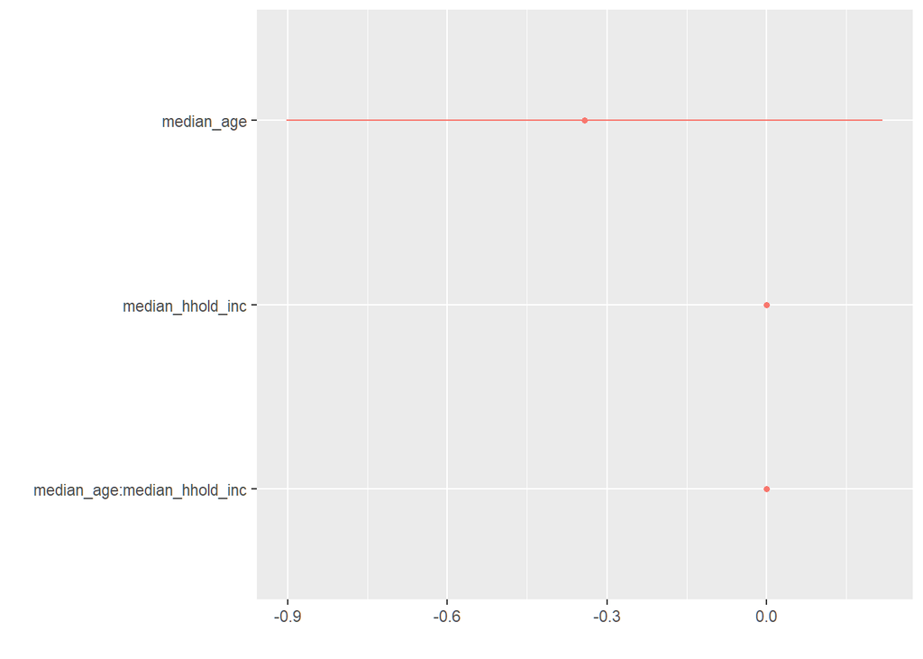

```r
library(ggplot2)
dwplot(model_2,by_2sd = F)
```

# Binary Regression

There is no binary data in our data, so we would like to add a column called high_risk, which means the percent of positive is more than the median of it.

```r
data$high_risk <- ifelse(data$precount_positive>median(data$precount_positive),1,0)
data$high_risk<-factor(data$high_risk)
```

### State the hypotheses

I assume that there is a relationship between high risk or not and median age of a tract. But whether it will be better if we add one more independent variable, median income. So we get these two hypotheses to compare.

```r
# Hypothesis 3: High risk or not has relationship with median age.
hypo3=formula(high_risk~median_age)
# Hypothesis 4: High risk or not has relationship with median age and median income.
hypo4=formula(high_risk~median_age*median_hhold_inc)
```

### Build and compute the regression models

We build two generalized linear models/logistic regression models for these two hypotheses.

```r
model_3=glm(hypo3,
         data=data,
         family="binomial")
model_4=glm(hypo4,
         data=data,
         family="binomial")
```

### Read the result

*Result for model/hypotheses 3*

```r
pander(summary(model_3))
```

|  | Estimate | Std. Error | z value | Pr(>\|z\|) |
| --- | --- | --- | --- | --- |
| **(Intercept)** | 3.691 | 0.8312 | 4.441 | 8.96e-06 |
| **median_age** | -0.1016 | 0.02165 | -4.692 | 2.708e-06 |

(Dispersion parameter for binomial family taken to be 1 )

| Null deviance: | 539.7 on 391 degrees of freedom |
| --- | --- |
| Residual deviance: | 514.7 on 390 degrees of freedom |

*Result for model/hypotheses 4*

```r
pander(summary(model_4))
```

|  | Estimate | Std. Error | z value | Pr(>\|z\|) |
| --- | --- | --- | --- | --- |
| **(Intercept)** | 1.772 | 2.669 | 0.6639 | 0.5067 |
| **median_age** | 0.01805 | 0.07044 | 0.2563 | 0.7978 |
| **median_hhold_inc** | 1.961e-06 | 2.884e-05 | 0.06798 | 0.9458 |
| **median_age:median_hhold_inc** | -7.555e-07 | 7.468e-07 | -1.012 | 0.3117 |

(Dispersion parameter for binomial family taken to be 1 )

| Null deviance: | 539.7 on 391 degrees of freedom |
| --- | --- |
| Residual deviance: | 455.8 on 388 degrees of freedom |

*Compare the two models and find the better one*

```r
lmtest::lrtest(model_3,model_4)
```

```
## Likelihood ratio test
##
## Model 1: high_risk ~ median_age
## Model 2: high_risk ~ median_age * median_hhold_inc
##   #Df  LogLik Df  Chisq Pr(>Chisq)
## 1   2 -257.34
## 2   4 -227.92  2 58.837  1.674e-13 ***
## ---
## Signif. codes:  0 '***' 0.001 '**' 0.01 '*' 0.05 '.' 0.1 ' ' 1
```

For comparing these two models, we use the likelihood-ratio test. From the result, due to the p-value = 1.674e-13, these two models has statistical differences. And model 4 is better than model 3.

### Get marginal effects

Logistics regression coefficients do not offer marginal effects on how much each variable affects the probability of the ‘1’ outcome. We can get it.

```r
library(margins)
(marginINFO = margins(model_4))
```

```
## Average marginal effects
```

```
## glm(formula = hypo4, family = "binomial", data = data)
```

```
##  median_age median_hhold_inc
##    -0.01067       -5.332e-06
```

```r
(marginSUMM=summary(marginINFO))
```

```
##            factor     AME     SE       z      p   lower   upper
##        median_age -0.0107 0.0055 -1.9410 0.0523 -0.0214  0.0001
##  median_hhold_inc -0.0000 0.0000 -5.0004 0.0000 -0.0000 -0.0000
```

### Get some plots

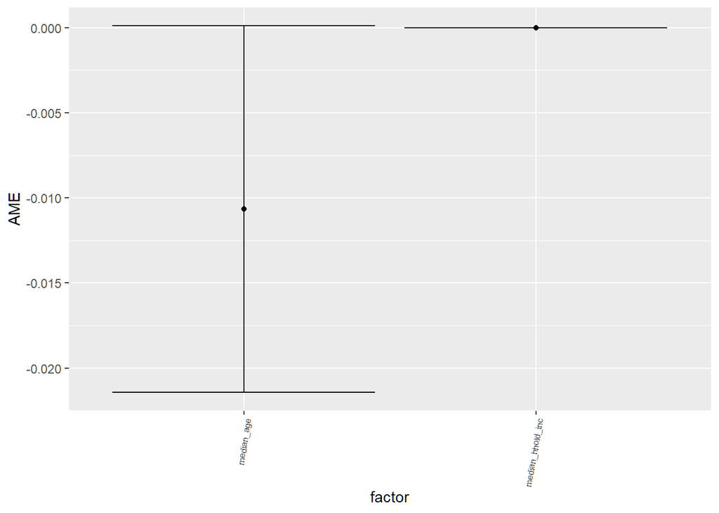

```r
base= ggplot(marginSUMM,
             aes(x=factor, y=AME))
base= base + geom_point()

plotMargins = base + theme(axis.text.x = element_text(angle = 80,size = 6,hjust = 1))
plotMargins +geom_errorbar(aes(ymin=lower, ymax=upper))
```

The interaction:

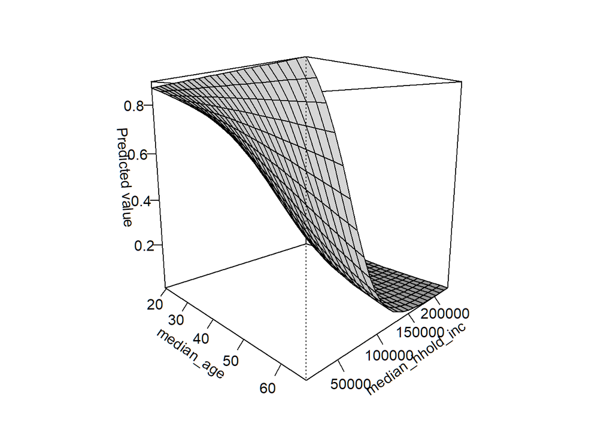

```r
persp(model_4)
```